# # Assignment 7

## Team Paramount

1. Akash Mishra
2. Gopi Chand Yenkipalli
3. Hiranmai Vallabhaneni
4. Rahul Bankey 5.Surya Teja Pidakala 6.Shanmukh Peela

```python
import pandas as pd
import numpy as np
from sklearn.model_selection import train_test_split
from sklearn.preprocessing import LabelEncoder
from sklearn.linear_model import LogisticRegression
from imblearn.over_sampling import RandomOverSampler
from sklearn.utils import resample
from sklearn.tree import DecisionTreeClassifier
from sklearn.neighbors import KNeighborsClassifier
from sklearn.metrics import confusion_matrix, accuracy_score, precision_score, recall_score, f1_score, plot_roc_curve, roc_auc_score, roc_curve, auc, RocCurveDisplay, PrecisionRecallDisplay, precision_recall_curve
from sklearn.model_selection import GridSearchCV, RandomizedSearchCV
from sklearn.metrics import classification_report
from sklearn.neural_network import MLPClassifier
from xgboost import XGBClassifier
#%%capture --no-display
from __future__ import print_function
from sklearn.neighbors import KNeighborsClassifier
from sklearn.metrics import classification_report
from sklearn import datasets
import sklearn
from sklearn.model_selection import train_test_split
import matplotlib.pyplot as plt
from sklearn import metrics
```

```
C:\Users\Gopi Chand\anaconda3\lib\site-packages\xgboost\compat.py:36: FutureWarning: pandas.Int64Index is deprecated and will be removed from pandas in a future version. Use pandas.Index with the appropriate dtype instead.
  from pandas import MultiIndex, Int64Index
```

```python
df = pd.read_csv("Movies_data.csv")
df
```

|  | MOVIE TITLE | RELEASE YEAR | RUNTIME | IMDB RATING | IMDB VOTES | WORLDWIDE GROSS | ESTIMATED BUDGET | PROFIT | MOVIE REVIEW |
| --- | --- | --- | --- | --- | --- | --- | --- | --- | --- |
| 0 | Avengers: Endgame | 2019 | 181 | 8.4 | 748670 | 2797800564 | 356000000 | 2441800564 | 1 |
| 1 | Avengers: Infinity War | 2018 | 149 | 8.4 | 792818 | 2048709917 | 321000000 | 1727709917 | 0 |
| 2 | Harry Potter and the Deathly Hallows: Part 2 | 2011 | 130 | 8.1 | 741462 | 1341511219 | 125000000 | 1216511219 | 0 |
| 3 | The Lord of the Rings: The Return of the King | 2003 | 201 | 8.9 | 1600809 | 1119929521 | 94000000 | 1025929521 | 0 |
| 4 | Joker | 2019 | 122 | 8.5 | 842794 | 1074251311 | 55000000 | 1019251311 | 0 |
| ... | ... | ... | ... | ... | ... | ... | ... | ... | ... |
| 468 | Mary Reilly | 1996 | 108 | 5.8 | 14573 | 12272308 | 47000000 | -34727692 | 1 |
| 469 | The Chamber | 1996 | 113 | 6.0 | 14749 | 7989000 | 50000000 | -42011000 | 0 |
| 470 | Speed 2: Cruise Control | 1997 | 121 | 3.9 | 78231 | 115900000 | 160000000 | -44100000 | 0 |
| 471 | Braveheart | 1995 | 178 | 8.3 | 984603 | 4259710 | 72000000 | -67740290 | 0 |
| 472 | Hercules | 1997 | 93 | 7.3 | 214521 | 806649 | 85000000 | -84193351 | 0 |

473 rows × 9 columns

```python
df.columns = [s.strip().upper().replace(' ', '_') for s in df.columns]
df.columns
```

```
Index(['MOVIE_TITLE', 'RELEASE_YEAR', 'RUNTIME', 'IMDB_RATING', 'IMDB_VOTES',
       'WORLDWIDE_GROSS', 'ESTIMATED_BUDGET', 'PROFIT', 'MOVIE_REVIEW'],
      dtype='object')
```

```python
#Drop unnecessary columns
df = df.drop(columns=['MOVIE_TITLE','RELEASE_YEAR','RUNTIME'])

# check for missing values
df.isnull().sum()
```

```
IMDB_RATING         0
IMDB_VOTES          0
WORLDWIDE_GROSS     0
ESTIMATED_BUDGET    0
PROFIT              0
MOVIE_REVIEW        0
dtype: int64
```

```python
df.dtypes
```

```
IMDB_RATING         float64
IMDB_VOTES            int64
WORLDWIDE_GROSS       int64
ESTIMATED_BUDGET      int64
PROFIT                int64
MOVIE_REVIEW          int64
dtype: object
```

```python
df.describe()
```

|  | IMDB_RATING | IMDB_VOTES | WORLDWIDE_GROSS | ESTIMATED_BUDGET | PROFIT | MOVIE_REVIEW |
| --- | --- | --- | --- | --- | --- | --- |
| count | 473.000000 | 4.730000e+02 | 4.730000e+02 | 4.730000e+02 | 4.730000e+02 | 473.000000 |
| mean | 7.109302 | 2.944162e+05 | 1.762117e+08 | 4.090416e+07 | 1.353075e+08 | 0.253700 |
| std | 1.142087 | 4.035539e+05 | 2.509800e+08 | 4.131413e+07 | 2.243844e+08 | 0.435589 |
| min | 3.200000 | 9.000000e+00 | 6.500000e+04 | 1.140000e+05 | -8.419335e+07 | 0.000000 |
| 25% | 6.400000 | 4.159100e+04 | 3.640000e+07 | 1.500000e+07 | 1.538126e+07 | 0.000000 |
| 50% | 7.200000 | 1.210370e+05 | 1.084314e+08 | 3.000000e+07 | 6.688900e+07 | 0.000000 |
| 75% | 8.100000 | 3.427530e+05 | 2.139288e+08 | 5.500000e+07 | 1.590467e+08 | 1.000000 |
| max | 9.300000 | 2.446424e+06 | 2.797801e+09 | 3.560000e+08 | 2.441801e+09 | 1.000000 |

```python
y = df.pop('MOVIE_REVIEW')
X = df
X_train,X_test,y_train,y_test=train_test_split(X,y,test_size=.3,random_state=0)
```

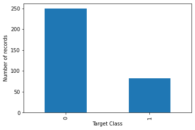

```python
import matplotlib.pyplot as plt
count = y_train.value_counts()
count.plot.bar()
plt.ylabel('Number of records')
plt.xlabel('Target Class')
plt.show()
```

```python
y_train.value_counts()
```

```
0    249
1     82
Name: MOVIE_REVIEW, dtype: int64
```

```python
ros = RandomOverSampler(random_state=0)
X_train, y_train = ros.fit_resample(X_train, y_train)
y_train.value_counts()
```

```
0    249
1    249
Name: MOVIE_REVIEW, dtype: int64
```

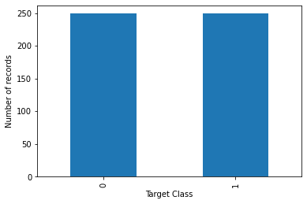

```python
import matplotlib.pyplot as plt
count = y_train.value_counts()
count.plot.bar()
plt.ylabel('Number of records')
plt.xlabel('Target Class')
plt.show()
```

## Normalization of data

```python
from sklearn.preprocessing import MinMaxScaler

scaler = MinMaxScaler(feature_range = (0,1))

scaler.fit(X_train)
X_train = scaler.transform(X_train)
X_test = scaler.transform(X_test)
```

## KNN with best k value using GridSearch

```python
grid_params = { 'n_neighbors' : list(range(1,120,2)),
               'weights' : ['uniform','distance'],
               'metric' : ['minkowski','euclidean','manhattan']}
```

```python
gs = GridSearchCV(KNeighborsClassifier(), grid_params, verbose = 1, cv=10, n_jobs = -1)
```

```python
g_res = gs.fit(X_train, y_train)
```

```
Fitting 10 folds for each of 360 candidates, totalling 3600 fits
```

```python
g_res.best_score_
```

```
0.8975510204081634
```

```python
g_res.best_params_
```

```
{'metric': 'minkowski', 'n_neighbors': 101, 'weights': 'distance'}
```

```python
%%time
knn = KNeighborsClassifier(n_neighbors = 101, weights = 'distance',metric = 'minkowski')
knn.fit(X_train, y_train)
```

```
CPU times: total: 0 ns
Wall time: 0 ns
```

```
KNeighborsClassifier(n_neighbors=101, weights='distance')
```

```python
%%time
%%capture --no-display

y_pred = knn.predict(X_test)
```

```
CPU times: total: 0 ns
Wall time: 7.08 ms
```

```python
confusion_matrix(y_test, y_pred)
```

```
array([[84, 20],
       [11, 27]], dtype=int64)
```

```python
print(classification_report(y_test, y_pred))
```

```
              precision    recall  f1-score   support

           0       0.88      0.81      0.84       104
           1       0.57      0.71      0.64        38

    accuracy                           0.78       142
   macro avg       0.73      0.76      0.74       142
weighted avg       0.80      0.78      0.79       142
```

```python
y_pred = knn.predict(X_test)
print(confusion_matrix(y_test, y_pred))
print("***********************")
print(f"{'Accuracy Score: ':18}{accuracy_score(y_test, y_pred):.3f}")
print("***********************")
print(f"{'Recall Score:':18}{recall_score(y_test, y_pred):.3f}")
print(f"{'Precision Score: ':18}{precision_score(y_test, y_pred):.3f}")
print(f"{'F1 Score: ':18}{f1_score(y_test, y_pred):.3f}")
print("***********************")
```

```
[[84 20]
 [11 27]]
Accuracy Score:   0.782
Recall Score:     0.711
Precision Score:  0.574
F1 Score:         0.635
```

As we can see from the confusion matrix that the values for TP,FP,FN,TN has a lot of difference, we are taking accuracy as it is the most contributing metric.

# Neural Network Model-1

```python
%%time

ann = MLPClassifier(hidden_layer_sizes=(60,50,40), solver='adam', max_iter=1000,random_state =1)
_ = ann.fit(X_train, y_train)
```

```
CPU times: total: 3.03 s
Wall time: 2.18 s
```

```python
%%time

y_pred = ann.predict(X_test)
```

```
CPU times: total: 0 ns
Wall time: 1 ms
```

```python
print(classification_report(y_test, y_pred))
```

```
              precision    recall  f1-score   support

           0       0.84      0.88      0.86       104
           1       0.62      0.53      0.57        38

    accuracy                           0.79       142
   macro avg       0.73      0.71      0.72       142
weighted avg       0.78      0.79      0.78       142
```

```python
confusion_matrix(y_test, y_pred)
```

```
array([[92, 12],
       [18, 20]], dtype=int64)
```

```python
y_pred = ann.predict(X_test)
print(confusion_matrix(y_test, y_pred))
print("***********************")
print(f"{'Accuracy Score: ':18}{accuracy_score(y_test, y_pred):.3f}")
print("***********************")
print(f"{'Recall Score:':18}{recall_score(y_test, y_pred):.3f}")
print(f"{'Precision Score: ':18}{precision_score(y_test, y_pred):.3f}")
print(f"{'F1 Score: ':18}{f1_score(y_test, y_pred):.3f}")
print("***********************")
```

```
[[92 12]
 [18 20]]
Accuracy Score:   0.789
Recall Score:     0.526
Precision Score:  0.625
F1 Score:         0.571
```

# Neural Network Model-2

```python
%%time

ann = MLPClassifier(hidden_layer_sizes=(80,70,60), solver='adam', max_iter=1000, random_state =1)
_ = ann.fit(X_train, y_train)
```

```
CPU times: total: 2.38 s
Wall time: 1.58 s
```

```python
%%time

y_pred = ann.predict(X_test)
```

```
CPU times: total: 0 ns
Wall time: 1.5 ms
```

```python
print(classification_report(y_test, y_pred))
```

```
              precision    recall  f1-score   support

           0       0.83      0.90      0.87       104
           1       0.66      0.50      0.57        38

    accuracy                           0.80       142
   macro avg       0.74      0.70      0.72       142
weighted avg       0.78      0.80      0.79       142
```

```python
confusion_matrix(y_test, y_pred)
```

```
array([[94, 10],
       [19, 19]], dtype=int64)
```

```python
y_pred = ann.predict(X_test)
print(confusion_matrix(y_test, y_pred))
print("***********************")
print(f"{'Accuracy Score: ':18}{accuracy_score(y_test, y_pred):.3f}")
print("***********************")
print(f"{'Recall Score:':18}{recall_score(y_test, y_pred):.3f}")
print(f"{'Precision Score: ':18}{precision_score(y_test, y_pred):.3f}")
print(f"{'F1 Score: ':18}{f1_score(y_test, y_pred):.3f}")
print("***********************")
```

```
[[94 10]
 [19 19]]
Accuracy Score:   0.796
Recall Score:     0.500
Precision Score:  0.655
F1 Score:         0.567
```

# Neural Network Model-3

```python
%%time

ann = MLPClassifier(hidden_layer_sizes=(40,30,20,10), solver='adam', max_iter=2000, random_state =1)
_ = ann.fit(X_train, y_train)
```

```
CPU times: total: 1.89 s
Wall time: 1.35 s
```

```python
%%time

y_pred = ann.predict(X_test)
```

```
CPU times: total: 0 ns
Wall time: 3.08 ms
```

```python
print(classification_report(y_test, y_pred))
```

```
              precision    recall  f1-score   support

           0       0.83      0.93      0.88       104
           1       0.72      0.47      0.57        38

    accuracy                           0.81       142
   macro avg       0.77      0.70      0.72       142
weighted avg       0.80      0.81      0.80       142
```

```python
confusion_matrix(y_test, y_pred)
```

```
array([[97,  7],
       [20, 18]], dtype=int64)
```

```python
y_pred = ann.predict(X_test)
print(confusion_matrix(y_test, y_pred))
print("***********************")
print(f"{'Accuracy Score: ':18}{accuracy_score(y_test, y_pred):.3f}")
print("***********************")
print(f"{'Recall Score:':18}{recall_score(y_test, y_pred):.3f}")
print(f"{'Precision Score: ':18}{precision_score(y_test, y_pred):.3f}")
print(f"{'F1 Score: ':18}{f1_score(y_test, y_pred):.3f}")
print("***********************")
```

```
[[97  7]
 [20 18]]
Accuracy Score:   0.810
Recall Score:     0.474
Precision Score:  0.720
F1 Score:         0.571
```

# Results

KNN Accuracy Score: 0.782

Neural Network Model-1 Accuracy Score: 0.789

Neural Network Model-2 Accuracy Score: 0.796

Neural Network Model-3 Accuracy Score: 0.810

# Interpretations

in KNN model, best k value is 101 , accuracy is 78.2 % Neural Network model -1, we consider 3 layer hidden layers of 60,50,40 neurons respectively and one bias added with each hidden layer and solver adam used. we got Accuracy Score of 78.9% which is better than knn model Neural Network model -2,we consider 3 layer hidden layers of 80,70,60 neurons respectively and one bias added with each hidden layer and solver adam used. we got Accuracy Score of 79.6% which is better than Neural Network model -1. Neural Network model -3,we consider 4 layer hidden layers of 40,30,20,10 neurons respectively and one bias added with each hidden layer and solver adam used. we got Accuracy Score of 81% which is better than Neural Network model -1 &2.

comapring nnm-1 and nnm2 in hit an dtrail method as neruons increased its accuracy increased however if neurons aare 100 or more there is decreasing in accuracy. comparing nnm-1 and nnm2 with nnm-3, same hit and trail method, as neruons decreased and one more layer added we got better results for nnm-3

# Comparing KNN and Neural network execution and prediction time

in KNN model classification and fitting takes less time CPU times: total: 0 ns Wall time: 0 ns than Neural networks (CPU times: total: 3.03 s Wall time: 2.18 s) and predications time is more in KNN (CPU times: total: 0 ns Wall time: 7.08 ms) than neural networks (CPU times: total: 0 ns Wall time: 1 ms)

# Comparing Neural network execution and prediction time

Neural Network Model-1 Accuracy Score: 0.789

model classification CPU times: total: 3.03 s Wall time: 2.18 s

model prediction CPU times: total: 0 ns Wall time: 1 ms

Neural Network Model-2 Accuracy Score: 0.796

model classification CPU times: total: 2.38 s Wall time: 1.58 s

model prediction CPU times: total: 0 ns Wall time: 1.5 ms

Neural Network Model-3 Accuracy Score: 0.810

model classification CPU times: total: 1.89 s Wall time: 1.35 s

model prediction CPU times: total: 0 ns Wall time: 3.08 ms

if we increasing layers or neurons- model classification and fitting CPU and wall time decreasing and execution speed increased and for predication, wall time increased as increasing in layers or neurons.